```python
%matplotlib inline
import seaborn
import numpy, scipy, sklearn, matplotlib.pyplot as plt, IPython.display as ipd, librosa, urllib
```

← Back to Index

# Classification of Separated Signals

After you have performed signal decomposition (e.g. using librosa.decompose.decompose), try to classify and combine the *separated* signals.

Download an audio file containing bass drum, snare drum, and hi-hat:

```python
filename = 'Classic Rock Beat 06.wav'
urllib.urlretrieve(
    'http://audio.musicinformationretrieval.com/Jam Pack 1/' + filename,
    filename=filename
)
```

```
('Classic Rock Beat 06.wav', <httplib.HTTPMessage instance at 0x10d52cfc8>)
```

Load the audio file into an array:

```python
x, fs = librosa.load(filename)
```

Listen to the audio:

```python
ipd.Audio(x, rate=fs)
```

[interactive chart not shown]

## Signal Decomposition

Compute the spectrogram:

```python
X = librosa.stft(x)
```

Save the magnitude and phase of the spectrogram for later use:

```python
Xabs = numpy.absolute(X)
Xphase = numpy.angle(X)
```

Perform nonnegative matrix factorization on the signal:

```python
n_components = 30
W, H = librosa.decompose.decompose(Xabs, n_components=n_components, sort=True)
print W.shape
print H.shape
```

```
(1025, 30)
(30, 296)
```

## Signal Component Reconstruction

Let's create a function that reconstructs a time-domain signal from the NMF outputs:

```python
def reconstruct_signal(w, h, Xphase, length=None):
    Y = scipy.outer(w, h)*numpy.exp(1j*Xphase)
    y = librosa.istft(Y)
    if length:
        y = librosa.util.fix_length(y, length)
    return y
```

Reconstruct each signal component:

```python
y_signals = numpy.array([reconstruct_signal(W[:,n], H[n], Xphase, length=len(x)) for n in range(n_components)])
```

Listen to one of the signal components:

```python
ipd.Audio(y_signals[29], rate=fs)
```

[interactive chart not shown]

## Feature Extraction

Compute features for each signal component.

```python
def normalize(h):
    return numpy.array(h)/scipy.linalg.norm(h)
```

```python
window_sz = 20
hop_sz = 10
features = numpy.array([
        [H[n, i:i+window_sz].mean() for i in range(0, H.shape[1]-window_sz, hop_sz)]
        for n in range(n_components)
])
```

```python
features.shape
```

```
(30, 28)
```

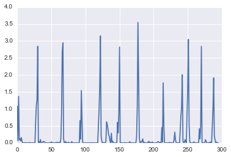

```python
plt.plot(H[0])
```

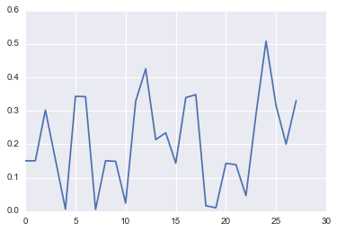

```python
plt.plot(features[0])
```

## Clustering

```python
model = sklearn.cluster.KMeans(n_clusters=3)
```

```python
labels = model.fit_predict(features)
```

```python
print labels
```

```
[2 2 0 0 1 1 1 0 2 0 0 0 0 0 0 2 2 0 0 0 0 0 0 0 0 0 0 0 0 0]
```

```python
bass_drum = y_signals[labels==0, :].sum(axis=0)
```

```python
ipd.Audio(bass_drum, rate=fs)
```

[interactive chart not shown]

```python
snare_drum = y_signals[labels==2, :].sum(axis=0)
```

```python
ipd.Audio(snare_drum, rate=fs)
```

[interactive chart not shown]

```python
hi_hat = y_signals[labels==1, :].sum(axis=0)
```

```python
ipd.Audio(hi_hat, rate=fs)
```

[interactive chart not shown]

```python
import numpy as np

labels = np.empty(20, np.int32)
labels[0:9] = 1 # First 10 are the first sample type, e.g. snare
labels[10:20] = 2 # Second 10 are the second sample type, e.g kick

model_snare = KNeighborsClassifier(n_neighbors = 1)
model.fit(scaledTrainingFeatures, labels.take(train_index, 0))
model_output = model_snare.predict(scaledTestingFeatures)
```

[output not shown]

1. Extract features from the drum signals that you separated in Lab 4 Section 1.
2. Classify them using the K-NN model that you built.

   Does K-NN accurately classify the separated signals?
3. Repeat for different numbers of separated signals (i.e., the parameter `K` in NMF).
4. Overseparate the signal using `K = 20` or more. For those separated components that are classified as snare, add them together using `sum}. The listen to the sum signal. Is it coherent, i.e., does it sound like a single separated drum?

...and more!

- If you have another idea that you would like to try out, please ask me!
- Feel free to collaborate with a partner. Together, brainstorm your own problems, if you want!

Good luck!

← Back to Index